# Data Analysis Task

Dandara Sousa

### O que é o dado?

Existem 9 variáveis nos dados sendo elas:

- session_id : Um id único identificando sessões individuais
- search_index : Um contador de buscas em uma mesma sessão ordenado cronologicamente
- session_start_timestamp: O timestamp que a sessão iniciou
- session_start_date : A data e hora que a sessão iniciou
- group : O grupo que pode ser “a” ou “b”
- results : A quantidade de resultados que a busca retornou
- num_clicks : O número de páginas que o usuário visitou a partir da busca
- first_click : A posição do link da página visitada no mecanismo de busca de páginas
- session_length : A duração em segundos da sessão

```r
buscas <- read_csv("../data/search_data.csv")
```

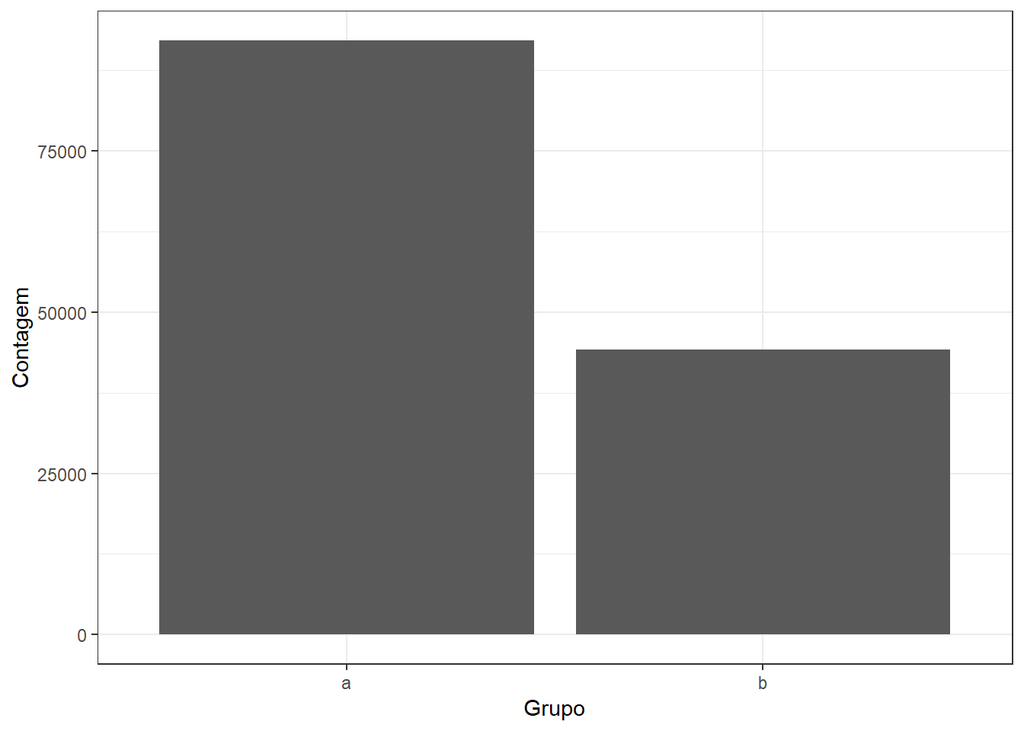

```r
buscas %>%
    ggplot(aes(group)) +
    geom_bar() +
    labs(x="Grupo", y="Contagem")
```

Por termos um desnível entre participação do grupo A e o grupo B. Vamos retirar aleatoriamente casos do número A para uma comparação mais justas entre grupos.

```r
buscas_b <- buscas %>%
    filter(group == "b")

b_lenght <- nrow(buscas_b)

buscas_a <- buscas %>%
    filter(group == "a")

buscas_a <- buscas_a[sample(nrow(buscas_a),b_lenght),]

buscas_igualadas <- rbind(buscas_a, buscas_b)
```

### O que queremos saber sobre ele?

#### Qual a nossa taxa diária de clickthrough rate? Como isso varia entre os grupos?

O Discovery Department da Wikimedia define `clickthrough rate` como a proporção de sessões onde o usuário clicou em um dos resultados mostrados. Com base nisso, o gráfico abaixo mostra a relação entre o clickthrough rate em cada dia. É possível ver que não há um padrão geral, mas que em no máximo 25% da sessões o usuário clica em algum resultado mostrado.

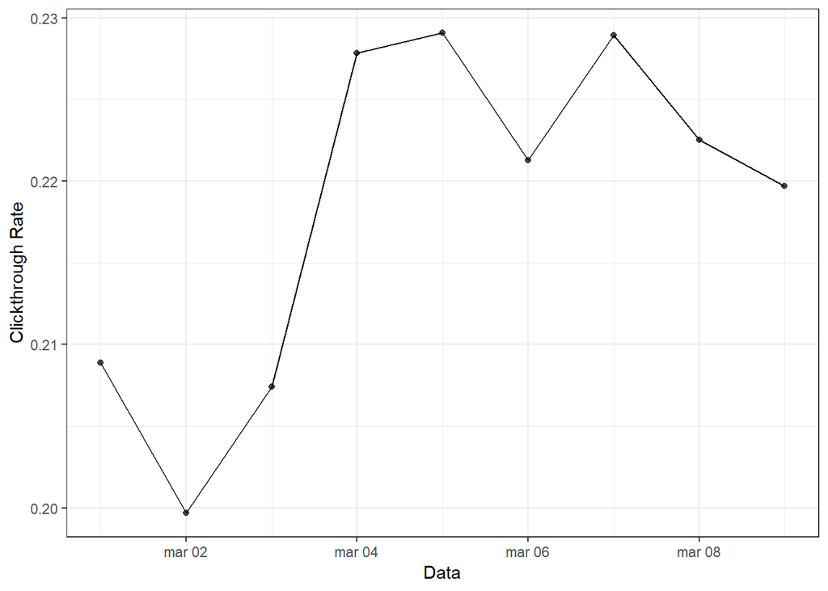

```r
buscas_igualadas <- buscas_igualadas %>%
    mutate(date = round_date(session_start_date, unit = "day"))

buscas_igualadas %>%
    group_by(date) %>%
    summarise(clickthrough_rate = sum(num_clicks > 0)/n()) %>%
    ggplot(aes(date,clickthrough_rate)) +
    geom_point(alpha = .7) +
    geom_line() +
    labs(x="Data", y="Clickthrough Rate")
```

Em relação a grupos, fica muito visível a diferença de comportamento entre eles. Enquanto o grupo A tende a interagir mais em suas pesquisas através dos cliques. O grupo B tem uma taxa bem inferior.

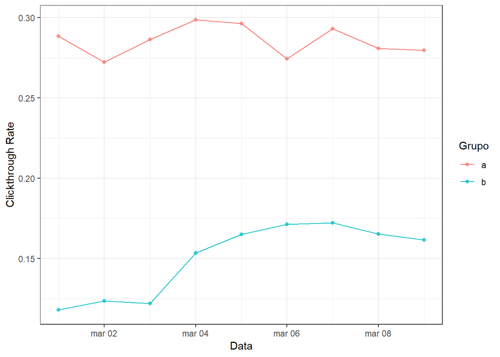

```r
buscas_igualadas %>%
    group_by(date, group) %>%
    summarise(clickthrough_rate = sum(num_clicks > 0)/n()) %>%
    ggplot(aes(date,clickthrough_rate, color = group)) +
    geom_point(alpha = .7) +
    geom_line() +
    labs(x="Data", y="Clickthrough Rate", colour = "Grupo")
```

#### Quais resultados as pessoas tendem a clicar primeiro? Como isso muda no dia-a-dia?

É esperado que as pessoas cliquem em geral no primeiro resultado que aparece uma vez que ele é o provável mais relevante naquele tipo de pesquisa. Então, além do comportamento padrão, qual seria o próximo?

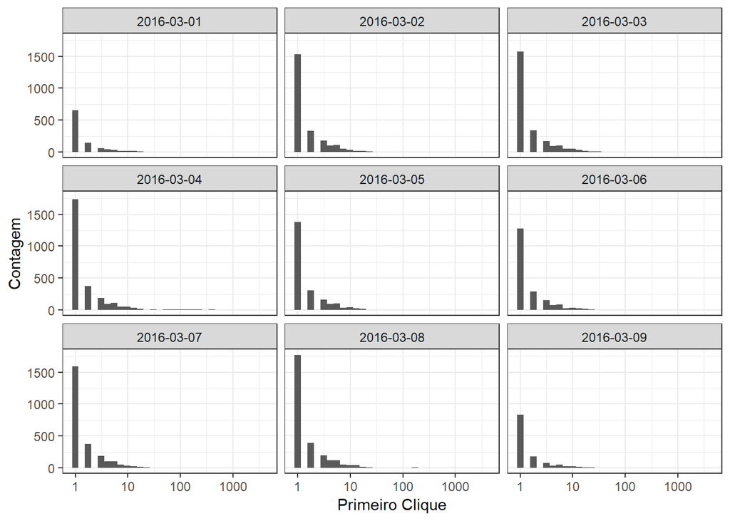

```r
buscas_igualadas %>%
    filter(!is.na(first_click)) %>%
    ggplot(aes(first_click)) +
    geom_histogram() +
    scale_x_log10() +
    facet_wrap(~date) +
    labs(x="Primeiro Clique", y="Contagem")
```

Abaixo percebemos que os primeiros links ainda são os mais vistos. É mais provável que o usuário nem chegue a segunda página da sua pesquisa.

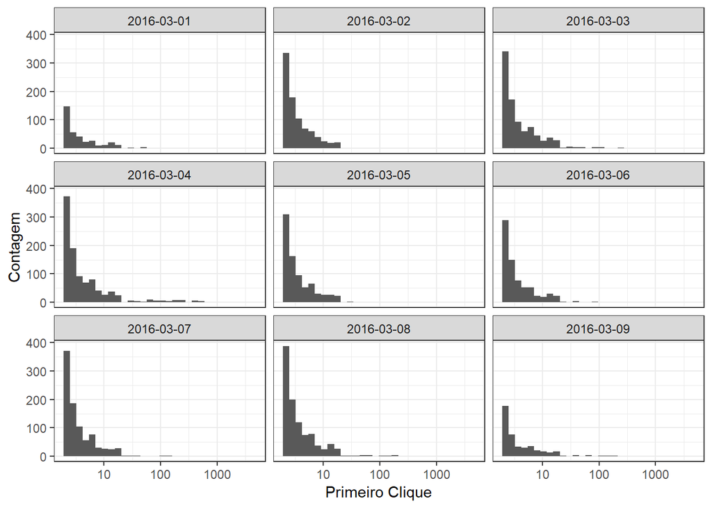

```r
buscas_igualadas %>%
    group_by(date, first_click) %>%
    filter(first_click > 1) %>%
    ggplot(aes(first_click)) +
    geom_histogram() +
    scale_x_log10() +
    facet_wrap(~date) +
    labs(x="Primeiro Clique", y="Contagem")
```

#### Qual a nossa taxa diária de zero results rate? Como isso varia entre os grupos?

O Discovery Department da Wikimedia define `zero results rate` como a proporção de buscas que retornou 0 resultados. A taxa diária é bem baixa, em geral menos de 20% quando analisamos sem distinção de grupos. Com a distinção podemos observar que não parece ter uma relação entre grupo de retorno zerado de resultados.

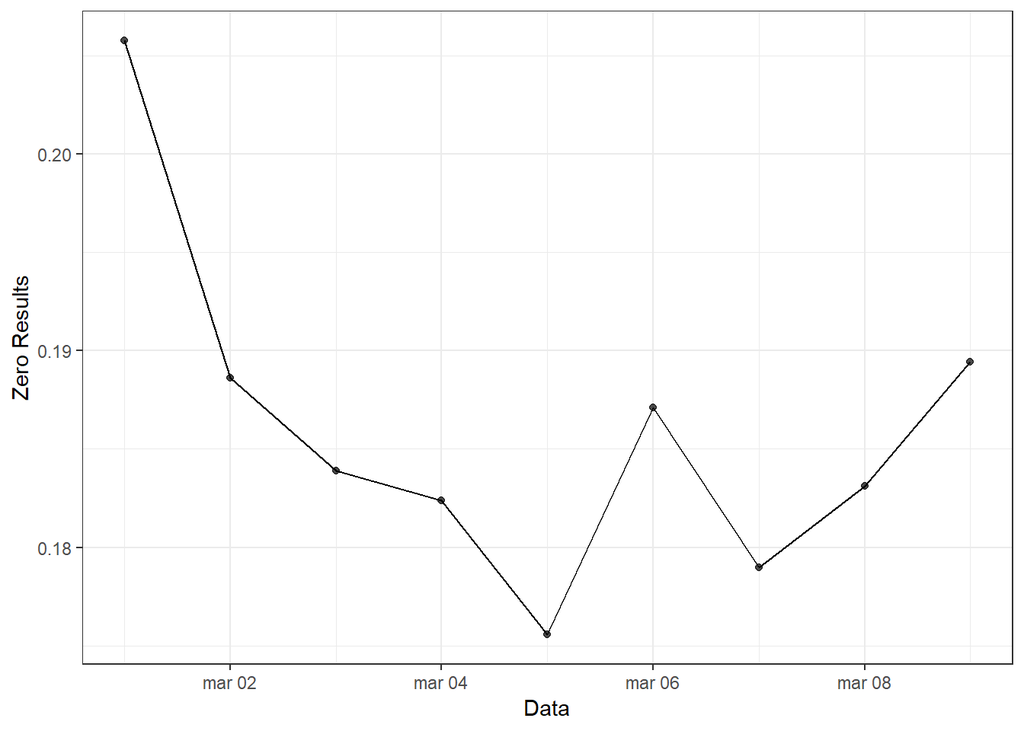

```r
buscas_igualadas %>%
    group_by(date) %>%
    summarise(zero_results = sum(results == 0)/n()) %>%
    ggplot(aes(date,zero_results)) +
    geom_point(alpha = .7) +
    geom_line() +
    labs(x="Data", y="Zero Results")
```

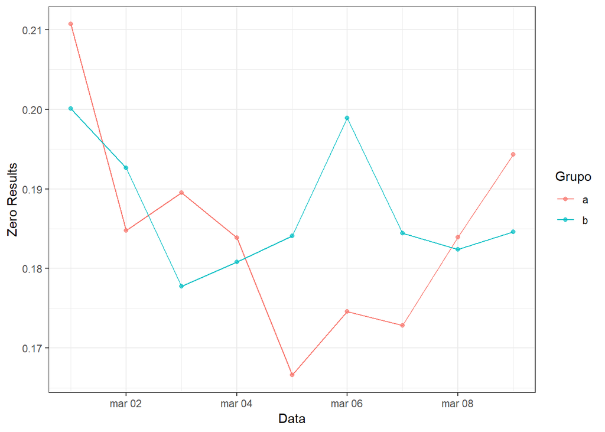

```r
buscas_igualadas %>%
    group_by(date, group) %>%
    summarise(zero_results = sum(results == 0)/n()) %>%
    ggplot(aes(date,zero_results, color = group)) +
    geom_point(alpha = .7) +
    geom_line() +
    labs(x="Data", y="Zero Results", color = "Grupo")
```

#### Considere a duração de cada sessão aproximadamente o tempo entre o primeiro e último evento de uma sessão. Escolha uma variável do conjunto de dados e descreva a relação com o tamanho da sessão. Visualise o relacionamento.

Aqui, a observação será entre o tamanho da sessão e e número de cliques que o usuário deu naquela sessão. Para isso, consideraremos sessões com tamanho maior que 0 por serem sessões onde possivelmente o usuário teve a chance de interagir com a busca.

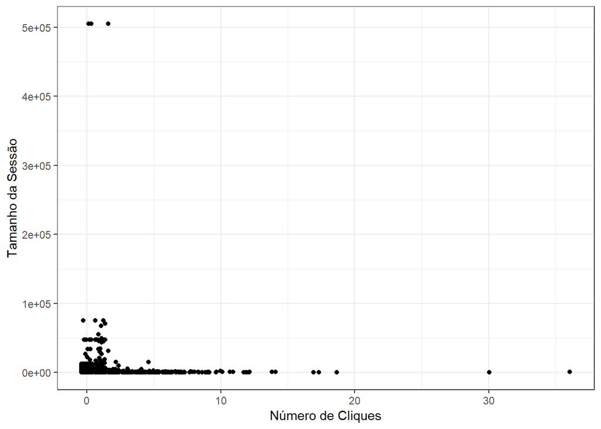

```r
buscas_igualadas %>%
    filter(session_length > 0) %>%
    ggplot(aes(num_clicks, session_length)) +
    geom_jitter() +
    labs(x="Número de Cliques", y="Tamanho da Sessão")
```

É notável um fato exorbitante de algumas poucas sessões com tamanho maior que 50000. Retirando esta parte para analisar o resto é visto que o usuário tende a passar menos tempo numa sessão quando ele clica muito nos resultados da busca. O que é algo positivo, afinal de conta podemos interpretar que ele encontrou resultados interessantes e passou menos tempo na página de busca.

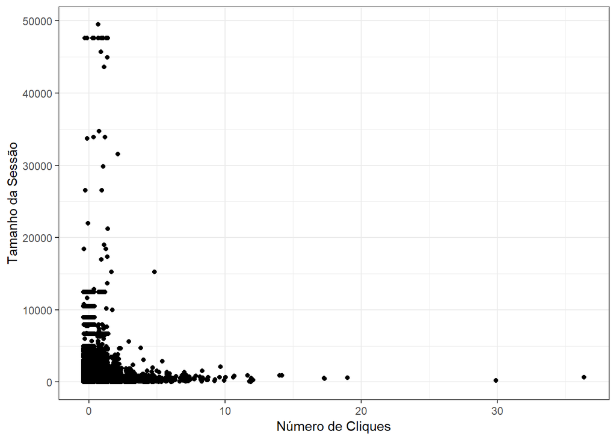

```r
buscas_igualadas %>%
    filter(session_length > 0, session_length < 50000) %>%
    ggplot(aes(num_clicks, session_length)) +
    geom_jitter()+
    labs(x="Número de Cliques", y="Tamanho da Sessão")
```